# 2 - Sentiment analysis_SOLVED

### Comparing two wordclouds in one ☁️☁️

Let’s compare positive wordcloud with negative wordcloud. To be able to plot two wordclouds in one, we need to install reshape2.

```r
# install.packages("reshape2")
```

```r
library(reshape2)
word_matrix <- tidy_austen_books %>%
  #we get sentiments
  inner_join(get_sentiments("bing")) %>%
  #we count word mentions
  count(word, sentiment, sort = TRUE) %>%
   #we convert to a matrix: rows = words, columns = sentiments, values = counts (0 if missing)
  acast(word ~ sentiment, value.var = "n", fill = 0)
head(word_matrix)
```

```
##            negative positive
## abominable       17        0
## abominably        7        0
## abominate         3        0
## abound            0        1
## abrupt            5        0
## abruptly         12        0
```

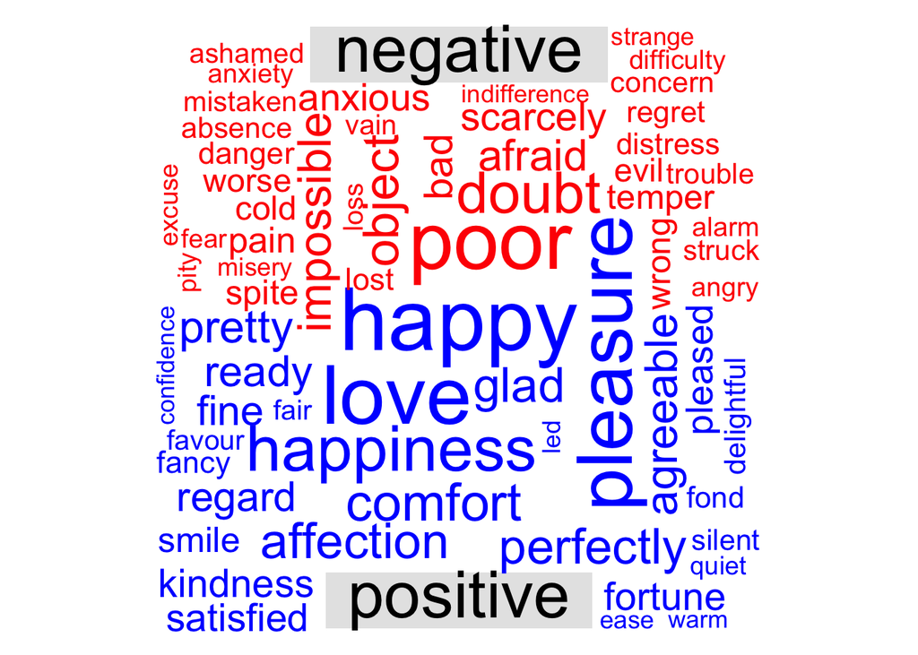

```r
#we paint two wordclouds in one using two different colors
#the colors are assigned in the same order as the columns in the matrix
comparison.cloud(word_matrix, colors = c("red", "blue"),
                   max.words = 100)
```

**Exercise**: repeat this wordcloud but only restricted to one book from Jane Austen, at your choice.

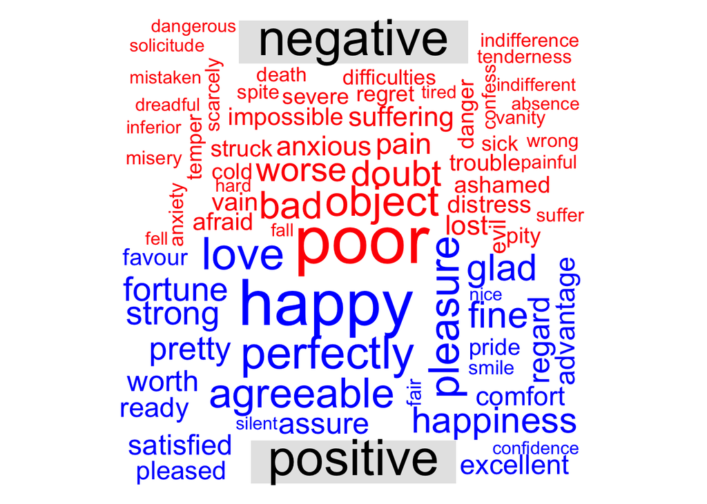

```r
library(reshape2)

tidy_austen_books %>%
  filter(book == "Persuasion") %>%
  #we get sentiments
  inner_join(get_sentiments("bing")) %>%
  #we count word mentions
  count(word, sentiment, sort = TRUE) %>%
  #we create the matrix
  acast(word ~ sentiment, value.var = "n", fill = 0) %>%
  #we paint two wordclouds in one using two different colors
  comparison.cloud(colors = c("red", "blue"),
                   max.words = 100)
```

## 5. Working sentence-level

So far, we have explored how to analyze sentiment at the word level. This approach can be useful depending on the project, for instance, if you want to create a word cloud.

Now, we are going to look at how to handle sentiment analysis at the **sentence or short text level.**

To do that, we need a library called `sentimentr`.

```r
#first, we install the package
# install.packages("sentimentr")
```

```r
#we try some sentences to see how it works
library(sentimentr)
texts <- c(
  "I love this book, it is amazing, super cool!",
  "I hate waiting for the train.",
  "The movie was okay, not bad but not great."
)

# calculate sentiment using function sentiment_by
texts_sentiments <- sentiment_by(texts)

texts_sentiments
```

|  | element_id | word_count | sd | ave_sentiment |
| --- | --- | --- | --- | --- |
| 1 | 1 | 9 | NA | 0.9166667 |
| 2 | 2 | 6 | NA | -0.3061862 |
| 3 | 3 | 9 | NA | 0.3747500 |

However, this output can be a bit confusing. Let’s select only what we are interested in and create a tibble with sentence and sentiment.

```r
#we create a tibble with two columns, sentence and sentiment
final_sentiment <- tibble(sentence = texts, sentiment = texts_sentiments$ave_sentiment)


final_sentiment
```

| sentence | sentiment |
| --- | --- |
| I love this book, it is amazing, super cool! | 0.9166667 |
| I hate waiting for the train. | -0.3061862 |
| The movie was okay, not bad but not great. | 0.3747500 |

Sentence-level sentiment analysis can look more modern or accurate, but it is not perfect either. Always look for the best option for your specific project.

## Summary

We have learned so far:

- How to use sentiment lexicons with different approaches
- How to analyze sentiment in the word-token level
- How to extract net sentiment of a chunk of lines
- How to plot the sentiment of a corpus to make a guess at its narrative distribution
- How to identify words that are contributing the most to sentiment analysis and how to fix mistakes
- How to find the most negative chapters in a book
- How to plot word clouds in black and white and color to illustrate our analysis
- How to analyze sentiment in the sentence or short text level